# AttBli Notebook

TODO: check on EOL warnings from csv file

# Attentional Blink PRE DATA ANALYSIS

ATTENTION BLINK BACKGROUND: http://www.scholarpedia.org/article/Attentional_blink N=55 (Control+Experimental) ^Missing data from sub7 There is a 3rd undefined group for those that have completed this task, but have dropped out for one reason or another.

## Data Prep

Getting the Data ready for analysis Defaults: R uses dummy coding as it’s default. In this sample, the control group and the 1-Back will be the dummy variables in the analysis. So all Estimates are relative to these dummy variables

### Load Requisite R Packages

note: some of these may not actually be used.

```r
library(ggplot2)
library(lme4)
library(languageR)
library(lmerTest)
library(influence.ME)
```

### Read in the dataset (in current directory)

```r
AttBli_data = read.table("AttBli_R_format.csv",
header = TRUE, sep = ",")
```

### Omit missing data (e.g. from practice trials)

```r
AttBli_data= na.omit(AttBli_data)
head(AttBli_data, n = 20)
```

### Omit the Undefined group from the data and specify group as a factor

```r
AttBli_data <- subset(AttBli_data,group=="Control" | group=="Experimental")
AttBli_data$group <- factor(AttBli_data$group)
summary(AttBli_data)
contrasts(AttBli_data$group)
```

### Isolate the session to the first session

```r
AttBli_data_pre <- subset(AttBli_data, session==1)
AttBli_data_pre$session <- factor(AttBli_data_pre$session)
summary(AttBli_data_pre)
```

### Specify subject as a factor

```r
AttBli_data_pre$subject <- as.factor(AttBli_data_pre$subject)

summary(AttBli_data_pre)
```

### Specify stimtype (probe in relation to cue) as a factor

Note: could treat this as a continuous variable instead of a discrete factor, up for debate. stimtype(-1,2,4,6,8)

```r
AttBli_data_pre$stimtype <- as.factor(AttBli_data_pre$stimtype)
summary(AttBli_data_pre)
```

## AttBli Accuracy Analysis

### Print out accuracy data for each subject for each group

Note: This is without filtering for whether the participant got the letter cue right or not.

```r
#subset data by experimental and control groups
AttBli_data_pre_control <- subset(AttBli_data_pre, group=="Control")
AttBli_data_pre_experimental <- subset(AttBli_data_pre, group=="Experimental")

#print control group data
g1 <- ggplot(data = AttBli_data_pre_control, aes(x = as.numeric(AttBli_data_pre_control$stimtype), y = AttBli_data_pre_control$probe_ACC))
g2 <- g1 + geom_point(alpha=.5) + geom_smooth(method='loess')
g3 <- g2 + scale_x_discrete(name = "distance from cue", limits=c("-1","2","4","6","8"))
g4 <- g3 + scale_y_discrete(name = "Probability of guessing existance of probe", limits=c(0,1))
g5 <- g4 + coord_cartesian(ylim =c(-.1,1.1), expand = FALSE) + facet_wrap(~subject) + ggtitle("Control Probe ACC")
print(g5)

#print experimental group data
g1 <- ggplot(data = AttBli_data_pre_experimental, aes(x = as.numeric(AttBli_data_pre_experimental$stimtype), y = AttBli_data_pre_experimental$probe_ACC))
g2 <- g1 + geom_point(alpha=.5) + geom_smooth(method='loess')
g3 <- g2 + scale_x_discrete(name = "distance from cue", limits=c("-1","2","4","6","8"))
g4 <- g3 + scale_y_discrete(name = "Probability of guessing existance of probe", limits=c(0,1))
g5 <- g4 + coord_cartesian(ylim =c(-.1,1.1), expand = FALSE) + facet_wrap(~subject) + ggtitle("Experimental Probe ACC")
print(g5)
```

[output not shown]

### Print out accuracy data for each subject for each group (filtering for letter cue accuracy)

Graphs where we only look at probe accuracy when the participant got the cue correct (matches the concept of attentional blink better)

```r
AttBli_data_pre_cue_filter <- subset(AttBli_data_pre, letter_ACC=="1")
#subset data by experimental and control groups
AttBli_data_pre_cue_filter_control <- subset(AttBli_data_pre_cue_filter, group=="Control")
AttBli_data_pre_cue_filter_experimental <- subset(AttBli_data_pre_cue_filter, group=="Experimental")

#print control group data
g1 <- ggplot(data = AttBli_data_pre_cue_filter_control, aes(x = as.numeric(stimtype), y = probe_ACC))
g2 <- g1 + geom_point(alpha=.5) + geom_smooth(method='loess')
g3 <- g2 + scale_x_discrete(name = "distance from cue", limits=c("-1","2","4","6","8"))
g4 <- g3 + scale_y_discrete(name = "Probability of guessing existance of probe", limits=c(0,1))
g5 <- g4 + coord_cartesian(ylim =c(-.1,1.1), expand = FALSE) + facet_wrap(~subject) + ggtitle("Control Probe ACC")
print(g5)

#print experimental group data
g1 <- ggplot(data = AttBli_data_pre_cue_filter_experimental, aes(x = as.numeric(stimtype), y = probe_ACC))
g2 <- g1 + geom_point(alpha=.5) + geom_smooth(method='loess')
g3 <- g2 + scale_x_discrete(name = "distance from cue", limits=c("-1","2","4","6","8"))
g4 <- g3 + scale_y_discrete(name = "Probability of guessing existance of probe", limits=c(0,1))
g5 <- g4 + coord_cartesian(ylim =c(-.1,1.1), expand = FALSE) + facet_wrap(~subject) + ggtitle("Experimental Probe ACC")
print(g5)
```

[output not shown]

### model probe Accuracy using logistic regression

Using the letter cue filtered data because it’s closer to what we want to test psychologically.

```r
probe_ACC_model<-glmer(probe_ACC ~ group*stimtype + (1|subject), family=binomial, data=AttBli_data_pre_cue_filter, verbose=TRUE)
summary(probe_ACC_model)
```

[output not shown]

### Print letter cue accuracy data

There were four choices so random guessing should give about 25% correct

```r
AttBli_data_pre_control <- subset(AttBli_data_pre, group=="Control")
AttBli_data_pre_experimental <- subset(AttBli_data_pre, group=="Experimental")

g1 <- ggplot(data = AttBli_data_pre_control, aes(x = as.numeric(AttBli_data_pre_control$stimtype), y = AttBli_data_pre_control$letter_ACC))
g2 <- g1 + geom_point(alpha=.5) + geom_smooth(method='loess')
g3 <- g2 + scale_x_discrete(name = "distance from cue", limits=c("-1","2","4","6","8"))
g4 <- g3 + scale_y_discrete(name = "Probability of guessing cue correctly", limits=c(0,1))
g5 <- g4 + coord_cartesian(ylim =c(-.1,1.1), expand = FALSE) + facet_wrap(~subject) + ggtitle("Control Cue Letter ACC")
print(g5)

g1 <- ggplot(data = AttBli_data_pre_experimental, aes(x = as.numeric(AttBli_data_pre_experimental$stimtype), y = AttBli_data_pre_experimental$letter_ACC))
g2 <- g1 + geom_point(alpha=.5) + geom_smooth(method='loess')
g3 <- g2 + scale_x_discrete(name = "distance from cue", limits=c("-1","2","4","6","8"))
g4 <- g3 + scale_y_discrete(name = "Probability of guessing cue correctly", limits=c(0,1))
g5 <- g4 + coord_cartesian(ylim =c(-.1,1.1), expand = FALSE) + facet_wrap(~subject) + ggtitle("Experimental Cue Letter ACC")
print(g5)
```

[output not shown]

### Model letter accuracy with logistic regression

```r
letter_ACC_model<-glmer(AttBli_data_pre$letter_ACC ~ group*stimtype + (1|subject), family=binomial, data=AttBli_data_pre, verbose=TRUE)
summary(letter_ACC_model)
```

[output not shown]

## AttBli Reaction Time Analysis

### Format RT data

(subset for RTs when they are accurate, greater than 200ms, and less than 3000 ms) ^The above thresholds were set somewhat arbitrarily, you can play with the thresholds. See how many observations are lost when we subset the data

```r
#all observations
print("All Data")
All_data_probe <- length(AttBli_data_pre$probe_RT)
summary(AttBli_data_pre)

#remove innacurate responses
print("Removed innacurate probe trials (from all data dataframe)")
AttBli_data_pre_probe_RT <- subset(AttBli_data_pre, probe_ACC==1)
All_Accurate_data_probe <- length(AttBli_data_pre_probe_RT$probe_RT)
summary(AttBli_data_pre_probe_RT)
#remove short and long RTs
print("Removed slow and fast RTs")
AttBli_data_pre_probe_RT <- subset(AttBli_data_pre_probe_RT, probe_RT>200 & probe_RT<3000)
filtered_data_probe <- length(AttBli_data_pre_probe_RT$probe_RT)
summary(AttBli_data_pre_probe_RT)

print("Percentage Probe Data Removed")
percent_data_rm_probe <- (1 - (filtered_data_probe/All_Accurate_data_probe)) * 100
percent_data_rm_probe

#remove innacurate responses
print("Removed innacurate letter trials (from all data dataframe")
AttBli_data_pre_letter_RT <- subset(AttBli_data_pre, letter_ACC==1)
All_Accurate_data_cue <- length(AttBli_data_pre_letter_RT$letter_RT)
summary(AttBli_data_pre_letter_RT)

#remove short and long RTs
print("Removed slow and fast RTs")
AttBli_data_pre_letter_RT <- subset(AttBli_data_pre_probe_RT, letter_RT>200 & letter_RT<3000)
filtered_data_cue <- length(AttBli_data_pre_letter_RT$letter_RT)
summary(AttBli_data_pre_letter_RT)

print("Percentage Cue Data Removed")
percent_data_rm_cue <- (1 - (filtered_data_cue/All_Accurate_data_cue)) * 100
percent_data_rm_cue
```

[output not shown]

### Graph probe RT data

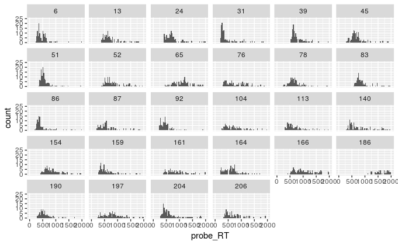

```r
AttBli_data_pre_probe_RT_control <- subset(AttBli_data_pre_probe_RT, group=="Control")
AttBli_data_pre_probe_RT_experimental <- subset(AttBli_data_pre_probe_RT, group=="Experimental")
RT_hist_control <- ggplot(data = AttBli_data_pre_probe_RT_control, aes(probe_RT)) + geom_histogram(binwidth = 30) + facet_wrap(~subject) + scale_y_continuous(limits = c(0,25)) + scale_x_continuous(limits = c(0,2000))
print(RT_hist_control)
```

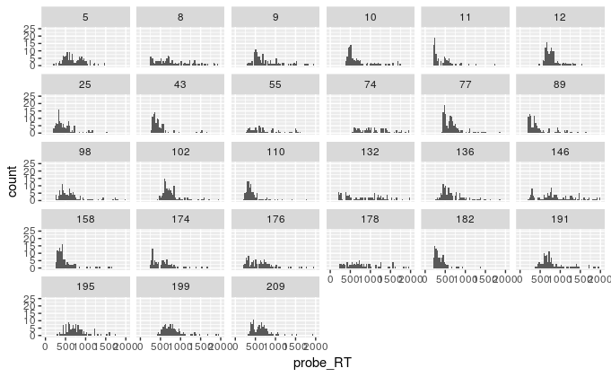

```r
RT_hist_experimental <- ggplot(data = AttBli_data_pre_probe_RT_experimental, aes(probe_RT)) + geom_histogram(binwidth = 30) + facet_wrap(~subject) + scale_y_continuous(limits = c(0,25)) + scale_x_continuous(limits = c(0,2000))
print(RT_hist_experimental)
```

**Conclusion**: Most participants show a right skew, going to log transform the data to see if they look better.

### Log transform RT data

```r
AttBli_data_pre_probe_RT$log_probe_RT <- log(1/AttBli_data_pre_probe_RT$probe_RT)
AttBli_data_pre_letter_RT$log_letter_RT <- log(1/AttBli_data_pre_letter_RT$letter_RT)
```

### Graph Log_probe_RT data

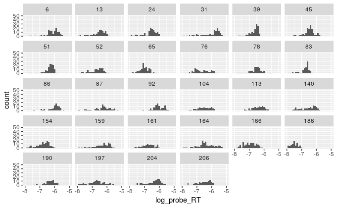

```r
AttBli_data_pre_probe_RT_control <- subset(AttBli_data_pre_probe_RT, group=="Control")
AttBli_data_pre_probe_RT_experimental <- subset(AttBli_data_pre_probe_RT, group=="Experimental")
#collapsing across stimtype (-1,2,4,6,8), not enough data to make a good histogram, and the graphs become too crowded if I include stimtype as a facet
RT_hist_control <- ggplot(data = AttBli_data_pre_probe_RT_control, aes(log_probe_RT)) + geom_histogram(binwidth = .1) + facet_wrap(~subject) + scale_y_continuous(limits = c(0,50)) + scale_x_continuous(limits = c(-8,-5))
print(RT_hist_control)
```

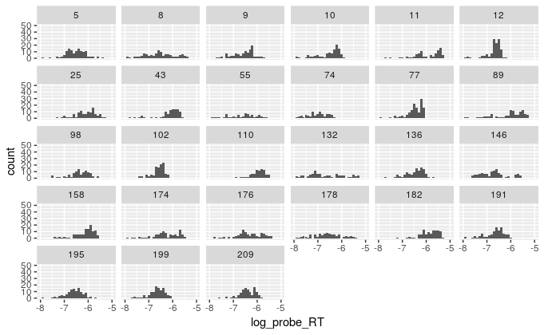

```r
RT_hist_experimental <- ggplot(data = AttBli_data_pre_probe_RT_experimental, aes(log_probe_RT)) + geom_histogram(binwidth = .1) + facet_wrap(~subject) + scale_y_continuous(limits = c(0,50)) + scale_x_continuous(limits = c(-8,-5))
print(RT_hist_experimental)
```

**Conclusion**: Probe Data overall looks more normally distributed.

### Model log Probe RT

```r
probe_RT_model <- lmer(log_probe_RT ~ group*stimtype + (1|subject), data = AttBli_data_pre_probe_RT)
summary(probe_RT_model)
```

```
Linear mixed model fit by REML t-tests use Satterthwaite approximations to degrees of  freedom
 [lmerMod]
Formula: log_probe_RT ~ group * stimtype + (1 | subject)
   Data: AttBli_data_pre_probe_RT

REML criterion at convergence: 7908.8

Scaled residuals:
    Min      1Q  Median      3Q     Max
-4.0592 -0.5168  0.1345  0.6513  2.9704

Random effects:
 Groups   Name        Variance Std.Dev.
 subject  (Intercept) 0.08683  0.2947
 Residual             0.21123  0.4596
Number of obs: 5969, groups:  subject, 55

Fixed effects:
                              Estimate Std. Error         df  t value Pr(>|t|)
(Intercept)                 -6.543e+00  5.683e-02  5.500e+01 -115.127   <2e-16 ***
groupExperimental            1.339e-01  8.109e-02  5.500e+01    1.651   0.1045
stimtype2                    3.966e-02  2.961e-02  5.914e+03    1.339   0.1806
stimtype4                   -1.718e-02  2.751e-02  5.911e+03   -0.624   0.5324
stimtype6                    4.949e-03  2.583e-02  5.909e+03    0.192   0.8481
stimtype8                   -2.703e-02  2.596e-02  5.910e+03   -1.041   0.2979
groupExperimental:stimtype2 -7.144e-02  4.633e-02  5.914e+03   -1.542   0.1231
groupExperimental:stimtype4 -5.413e-02  3.996e-02  5.911e+03   -1.355   0.1756
groupExperimental:stimtype6 -3.730e-02  3.749e-02  5.910e+03   -0.995   0.3198
groupExperimental:stimtype8 -7.969e-02  3.729e-02  5.910e+03   -2.137   0.0326 *
---
Signif. codes:  0 ‘***’ 0.001 ‘**’ 0.01 ‘*’ 0.05 ‘.’ 0.1 ‘ ’ 1

Correlation of Fixed Effects:
            (Intr) grpExp stmty2 stmty4 stmty6 stmty8 grpE:2 grpE:4 grpE:6
grpExprmntl -0.701
stimtype2   -0.078  0.055
stimtype4   -0.083  0.058  0.171
stimtype6   -0.087  0.061  0.177  0.188
stimtype8   -0.088  0.062  0.176  0.185  0.194
grpExprmn:2  0.050 -0.070 -0.639 -0.109 -0.113 -0.112
grpExprmn:4  0.057 -0.080 -0.117 -0.688 -0.129 -0.127  0.155
grpExprmn:6  0.060 -0.085 -0.122 -0.129 -0.689 -0.133  0.158  0.182
grpExprmn:8  0.061 -0.086 -0.122 -0.129 -0.135 -0.696  0.159  0.181  0.190
```

**Conclusion**: No overall Group effect (as expected), but there is an interaction between group and the largest distance between cue and probe. I don’t know if this is worth investigating or to chalk it up to having so many comparisons.

### Model logged letter RT by group and lag

```r
letter_RT_model <- lmer(log_letter_RT ~ group*stimtype + (1|subject), data = AttBli_data_pre_letter_RT)
summary(letter_RT_model)
```

```
Linear mixed model fit by REML t-tests use Satterthwaite approximations to degrees of  freedom
 [lmerMod]
Formula: log_letter_RT ~ group * stimtype + (1 | subject)
   Data: AttBli_data_pre_letter_RT

REML criterion at convergence: 971

Scaled residuals:
    Min      1Q  Median      3Q     Max
-4.3635 -0.5463  0.1335  0.6400  5.1757

Random effects:
 Groups   Name        Variance Std.Dev.
 subject  (Intercept) 0.02658  0.1630
 Residual             0.06625  0.2574
Number of obs: 5767, groups:  subject, 55

Fixed effects:
                              Estimate Std. Error         df  t value Pr(>|t|)
(Intercept)                 -7.256e+00  3.149e-02  5.500e+01 -230.414   <2e-16 ***
groupExperimental            3.097e-02  4.493e-02  5.500e+01    0.689   0.4935
stimtype2                    1.539e-01  1.679e-02  5.712e+03    9.164   <2e-16 ***
stimtype4                    1.703e-01  1.555e-02  5.709e+03   10.952   <2e-16 ***
stimtype6                    1.283e-01  1.466e-02  5.707e+03    8.750   <2e-16 ***
stimtype8                    2.625e-02  1.478e-02  5.708e+03    1.776   0.0757 .
groupExperimental:stimtype2 -3.651e-02  2.642e-02  5.713e+03   -1.382   0.1670
groupExperimental:stimtype4 -3.653e-03  2.264e-02  5.710e+03   -0.161   0.8718
groupExperimental:stimtype6 -4.919e-03  2.126e-02  5.708e+03   -0.231   0.8171
groupExperimental:stimtype8 -4.020e-02  2.124e-02  5.709e+03   -1.893   0.0585 .
---
Signif. codes:  0 ‘***’ 0.001 ‘**’ 0.01 ‘*’ 0.05 ‘.’ 0.1 ‘ ’ 1

Correlation of Fixed Effects:
            (Intr) grpExp stmty2 stmty4 stmty6 stmty8 grpE:2 grpE:4 grpE:6
grpExprmntl -0.701
stimtype2   -0.081  0.057
stimtype4   -0.087  0.061  0.174
stimtype6   -0.091  0.064  0.180  0.191
stimtype8   -0.091  0.064  0.179  0.189  0.197
grpExprmn:2  0.052 -0.073 -0.636 -0.111 -0.114 -0.114
grpExprmn:4  0.060 -0.084 -0.119 -0.687 -0.131 -0.129  0.157
grpExprmn:6  0.063 -0.088 -0.124 -0.132 -0.689 -0.135  0.160  0.185
grpExprmn:8  0.063 -0.089 -0.125 -0.131 -0.137 -0.696  0.161  0.184  0.192
```

## Conclusions

Good: No overall Group differences in Reaction Time or Accuracy